# Risk Factor Analysis

## Outcome Variable

**Outcome Variable:** wast_rec90d

## Predictor Variables

**Intervention Variable:** mbmi

**Adjustment Set:**

- arm
- W_mage
- meducyrs
- feducyrs
- hhwealth_quart
- W_nchldlt5
- brthmon
- W_parity
- impfloor
- delta_W_mage
- delta_meducyrs
- delta_feducyrs
- delta_hhwealth_quart
- delta_W_nchldlt5
- delta_brthmon
- delta_W_parity
- delta_impfloor

## Stratifying Variables

The analysis was stratified on these variable(s):

- agecat
- studyid
- country

## Data Summary

| agecat | studyid | country | mbmi | wast_rec90d | n_cell | n |
| --- | --- | --- | --- | --- | --- | --- |
| 0-24 months | ki0047075b-MAL-ED | BANGLADESH | Normal weight | 0 | 30 | 122 |
| 0-24 months | ki0047075b-MAL-ED | BANGLADESH | Normal weight | 1 | 64 | 122 |
| 0-24 months | ki0047075b-MAL-ED | BANGLADESH | Underweight | 0 | 13 | 122 |
| 0-24 months | ki0047075b-MAL-ED | BANGLADESH | Underweight | 1 | 15 | 122 |
| 0-24 months | ki0047075b-MAL-ED | BRAZIL | Normal weight | 0 | 6 | 23 |
| 0-24 months | ki0047075b-MAL-ED | BRAZIL | Normal weight | 1 | 15 | 23 |
| 0-24 months | ki0047075b-MAL-ED | BRAZIL | Underweight | 0 | 0 | 23 |
| 0-24 months | ki0047075b-MAL-ED | BRAZIL | Underweight | 1 | 2 | 23 |
| 0-24 months | ki0047075b-MAL-ED | INDIA | Normal weight | 0 | 49 | 178 |
| 0-24 months | ki0047075b-MAL-ED | INDIA | Normal weight | 1 | 82 | 178 |
| 0-24 months | ki0047075b-MAL-ED | INDIA | Underweight | 0 | 21 | 178 |
| 0-24 months | ki0047075b-MAL-ED | INDIA | Underweight | 1 | 26 | 178 |
| 0-24 months | ki0047075b-MAL-ED | NEPAL | Normal weight | 0 | 20 | 98 |
| 0-24 months | ki0047075b-MAL-ED | NEPAL | Normal weight | 1 | 78 | 98 |
| 0-24 months | ki0047075b-MAL-ED | NEPAL | Underweight | 0 | 0 | 98 |
| 0-24 months | ki0047075b-MAL-ED | NEPAL | Underweight | 1 | 0 | 98 |
| 0-24 months | ki0047075b-MAL-ED | PERU | Normal weight | 0 | 5 | 35 |
| 0-24 months | ki0047075b-MAL-ED | PERU | Normal weight | 1 | 26 | 35 |
| 0-24 months | ki0047075b-MAL-ED | PERU | Underweight | 0 | 1 | 35 |
| 0-24 months | ki0047075b-MAL-ED | PERU | Underweight | 1 | 3 | 35 |
| 0-24 months | ki0047075b-MAL-ED | SOUTH AFRICA | Normal weight | 0 | 14 | 80 |
| 0-24 months | ki0047075b-MAL-ED | SOUTH AFRICA | Normal weight | 1 | 66 | 80 |
| 0-24 months | ki0047075b-MAL-ED | SOUTH AFRICA | Underweight | 0 | 0 | 80 |
| 0-24 months | ki0047075b-MAL-ED | SOUTH AFRICA | Underweight | 1 | 0 | 80 |
| 0-24 months | ki0047075b-MAL-ED | TANZANIA, UNITED REPUBLIC OF | Normal weight | 0 | 8 | 51 |
| 0-24 months | ki0047075b-MAL-ED | TANZANIA, UNITED REPUBLIC OF | Normal weight | 1 | 38 | 51 |
| 0-24 months | ki0047075b-MAL-ED | TANZANIA, UNITED REPUBLIC OF | Underweight | 0 | 1 | 51 |
| 0-24 months | ki0047075b-MAL-ED | TANZANIA, UNITED REPUBLIC OF | Underweight | 1 | 4 | 51 |
| 0-24 months | ki1000304b-SAS-CompFeed | INDIA | Normal weight | 0 | 288 | 744 |
| 0-24 months | ki1000304b-SAS-CompFeed | INDIA | Normal weight | 1 | 185 | 744 |

[output cut: 170 more lines]

The following strata were considered:

- agecat: 0-24 months, studyid: ki0047075b-MAL-ED, country: BANGLADESH
- agecat: 0-24 months, studyid: ki0047075b-MAL-ED, country: BRAZIL
- agecat: 0-24 months, studyid: ki0047075b-MAL-ED, country: INDIA
- agecat: 0-24 months, studyid: ki0047075b-MAL-ED, country: NEPAL
- agecat: 0-24 months, studyid: ki0047075b-MAL-ED, country: PERU
- agecat: 0-24 months, studyid: ki0047075b-MAL-ED, country: SOUTH AFRICA
- agecat: 0-24 months, studyid: ki0047075b-MAL-ED, country: TANZANIA, UNITED REPUBLIC OF
- agecat: 0-24 months, studyid: ki1000304b-SAS-CompFeed, country: INDIA
- agecat: 0-24 months, studyid: ki1017093-NIH-Birth, country: BANGLADESH
- agecat: 0-24 months, studyid: ki1017093b-PROVIDE, country: BANGLADESH
- agecat: 0-24 months, studyid: ki1017093c-NIH-Crypto, country: BANGLADESH
- agecat: 0-24 months, studyid: ki1066203-TanzaniaChild2, country: TANZANIA, UNITED REPUBLIC OF
- agecat: 0-24 months, studyid: ki1112895-iLiNS-Zinc, country: BURKINA FASO
- agecat: 0-24 months, studyid: ki1119695-PROBIT, country: BELARUS
- agecat: 0-24 months, studyid: ki1126311-ZVITAMBO, country: ZIMBABWE
- agecat: 0-24 months, studyid: ki1148112-LCNI-5, country: MALAWI
- agecat: 0-24 months, studyid: kiGH5241-JiVitA-3, country: BANGLADESH
- agecat: 0-6 months, studyid: ki0047075b-MAL-ED, country: BANGLADESH
- agecat: 0-6 months, studyid: ki0047075b-MAL-ED, country: BRAZIL
- agecat: 0-6 months, studyid: ki0047075b-MAL-ED, country: INDIA
- agecat: 0-6 months, studyid: ki0047075b-MAL-ED, country: NEPAL
- agecat: 0-6 months, studyid: ki0047075b-MAL-ED, country: PERU
- agecat: 0-6 months, studyid: ki0047075b-MAL-ED, country: SOUTH AFRICA
- agecat: 0-6 months, studyid: ki0047075b-MAL-ED, country: TANZANIA, UNITED REPUBLIC OF
- agecat: 0-6 months, studyid: ki1000304b-SAS-CompFeed, country: INDIA
- agecat: 0-6 months, studyid: ki1017093-NIH-Birth, country: BANGLADESH
- agecat: 0-6 months, studyid: ki1017093b-PROVIDE, country: BANGLADESH
- agecat: 0-6 months, studyid: ki1017093c-NIH-Crypto, country: BANGLADESH
- agecat: 0-6 months, studyid: ki1066203-TanzaniaChild2, country: TANZANIA, UNITED REPUBLIC OF
- agecat: 0-6 months, studyid: ki1119695-PROBIT, country: BELARUS
- agecat: 0-6 months, studyid: ki1126311-ZVITAMBO, country: ZIMBABWE
- agecat: 0-6 months, studyid: ki1148112-LCNI-5, country: MALAWI
- agecat: 0-6 months, studyid: kiGH5241-JiVitA-3, country: BANGLADESH
- agecat: 6-24 months, studyid: ki0047075b-MAL-ED, country: BANGLADESH
- agecat: 6-24 months, studyid: ki0047075b-MAL-ED, country: BRAZIL
- agecat: 6-24 months, studyid: ki0047075b-MAL-ED, country: INDIA
- agecat: 6-24 months, studyid: ki0047075b-MAL-ED, country: NEPAL
- agecat: 6-24 months, studyid: ki0047075b-MAL-ED, country: PERU
- agecat: 6-24 months, studyid: ki0047075b-MAL-ED, country: SOUTH AFRICA
- agecat: 6-24 months, studyid: ki0047075b-MAL-ED, country: TANZANIA, UNITED REPUBLIC OF
- agecat: 6-24 months, studyid: ki1000304b-SAS-CompFeed, country: INDIA
- agecat: 6-24 months, studyid: ki1017093-NIH-Birth, country: BANGLADESH
- agecat: 6-24 months, studyid: ki1017093b-PROVIDE, country: BANGLADESH
- agecat: 6-24 months, studyid: ki1017093c-NIH-Crypto, country: BANGLADESH
- agecat: 6-24 months, studyid: ki1066203-TanzaniaChild2, country: TANZANIA, UNITED REPUBLIC OF
- agecat: 6-24 months, studyid: ki1112895-iLiNS-Zinc, country: BURKINA FASO
- agecat: 6-24 months, studyid: ki1119695-PROBIT, country: BELARUS
- agecat: 6-24 months, studyid: ki1126311-ZVITAMBO, country: ZIMBABWE
- agecat: 6-24 months, studyid: ki1148112-LCNI-5, country: MALAWI
- agecat: 6-24 months, studyid: kiGH5241-JiVitA-3, country: BANGLADESH

### Dropped Strata

Some strata were dropped due to rare outcomes:

- agecat: 0-24 months, studyid: ki0047075b-MAL-ED, country: BRAZIL
- agecat: 0-24 months, studyid: ki0047075b-MAL-ED, country: NEPAL
- agecat: 0-24 months, studyid: ki0047075b-MAL-ED, country: PERU
- agecat: 0-24 months, studyid: ki0047075b-MAL-ED, country: SOUTH AFRICA
- agecat: 0-24 months, studyid: ki0047075b-MAL-ED, country: TANZANIA, UNITED REPUBLIC OF
- agecat: 0-6 months, studyid: ki0047075b-MAL-ED, country: BRAZIL
- agecat: 0-6 months, studyid: ki0047075b-MAL-ED, country: NEPAL
- agecat: 0-6 months, studyid: ki0047075b-MAL-ED, country: PERU
- agecat: 0-6 months, studyid: ki0047075b-MAL-ED, country: SOUTH AFRICA
- agecat: 0-6 months, studyid: ki0047075b-MAL-ED, country: TANZANIA, UNITED REPUBLIC OF
- agecat: 0-6 months, studyid: ki1017093c-NIH-Crypto, country: BANGLADESH
- agecat: 0-6 months, studyid: ki1066203-TanzaniaChild2, country: TANZANIA, UNITED REPUBLIC OF
- agecat: 0-6 months, studyid: ki1148112-LCNI-5, country: MALAWI
- agecat: 6-24 months, studyid: ki0047075b-MAL-ED, country: BRAZIL
- agecat: 6-24 months, studyid: ki0047075b-MAL-ED, country: NEPAL
- agecat: 6-24 months, studyid: ki0047075b-MAL-ED, country: PERU
- agecat: 6-24 months, studyid: ki0047075b-MAL-ED, country: SOUTH AFRICA
- agecat: 6-24 months, studyid: ki0047075b-MAL-ED, country: TANZANIA, UNITED REPUBLIC OF
- agecat: 6-24 months, studyid: ki1017093c-NIH-Crypto, country: BANGLADESH
- agecat: 6-24 months, studyid: ki1066203-TanzaniaChild2, country: TANZANIA, UNITED REPUBLIC OF
- agecat: 6-24 months, studyid: ki1119695-PROBIT, country: BELARUS
- agecat: 6-24 months, studyid: kiGH5241-JiVitA-3, country: BANGLADESH

## Methods Detail

We’re interested in the causal parameters $E[Y_a]$ for all values of $a \in \mathcal{A}$. These parameters represent the mean outcome if, possibly contrary to fact, we intervened to set all units to have $A=a$. Under the randomization and positivity assumptions, these are identified by the statistical parameters $\psi_a=E_W[E_{Y|A,W}(Y|A=a,W)]$. In addition, we’re interested in the mean of $Y$, $E[Y]$ under no intervention (the observed mean). We will estimate these parameters by using SuperLearner to fit the relevant likelihood factors – $E_{Y|A,W}(Y|A=a,W)$ and $p(A=a|W)$, and then updating our likelihood fit using a joint TMLE.

For unadjusted analyses ($W=\{\}$), initial likelihoods were estimated using Lrnr_glm to estimate the simple $E(Y|A)$ and Lrnr_mean to estimate $p(A)$. For adjusted analyses, a small library containing Lrnr_glmnet, Lrnr_xgboost, and Lrnr_mean was used.

Having estimated these parameters, we will then use the delta method to estimate relative risks and attributable risks relative to a prespecified baseline level of $A$.

# Results Detail

## Results Plots

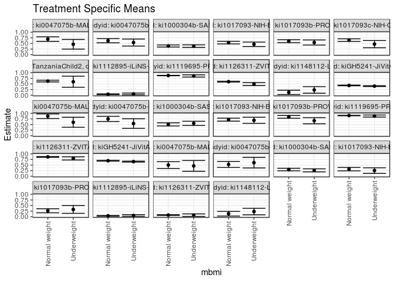

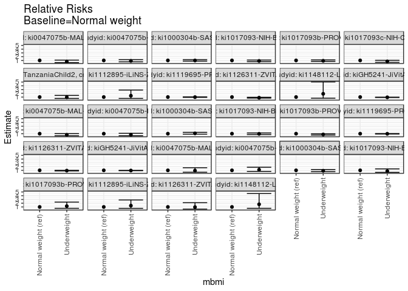

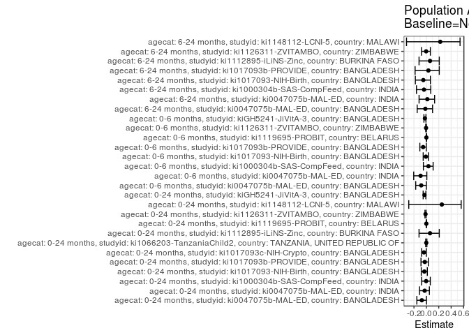

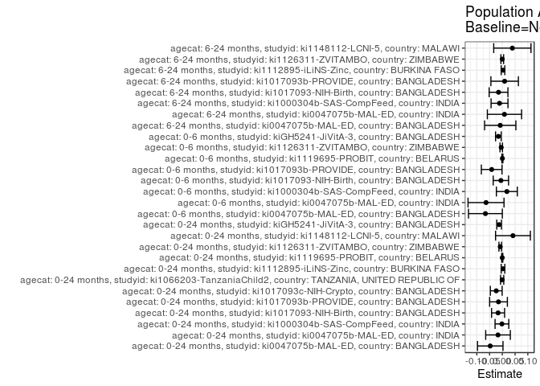

## Results Table

### Parameter: TSM

| agecat | studyid | country | intervention_level | baseline_level | estimate | ci_lower | ci_upper |
| --- | --- | --- | --- | --- | --- | --- | --- |
| 0-24 months | ki0047075b-MAL-ED | BANGLADESH | Normal weight | NA | 0.6949134 | 0.5929071 | 0.7969197 |
| 0-24 months | ki0047075b-MAL-ED | BANGLADESH | Underweight | NA | 0.4631959 | 0.2480844 | 0.6783074 |
| 0-24 months | ki0047075b-MAL-ED | INDIA | Normal weight | NA | 0.6236515 | 0.5302827 | 0.7170204 |
| 0-24 months | ki0047075b-MAL-ED | INDIA | Underweight | NA | 0.5407529 | 0.3842519 | 0.6972539 |
| 0-24 months | ki1000304b-SAS-CompFeed | INDIA | Normal weight | NA | 0.3859668 | 0.3384645 | 0.4334690 |
| 0-24 months | ki1000304b-SAS-CompFeed | INDIA | Underweight | NA | 0.3805396 | 0.3227435 | 0.4383356 |
| 0-24 months | ki1017093-NIH-Birth | BANGLADESH | Normal weight | NA | 0.5367963 | 0.4781617 | 0.5954309 |
| 0-24 months | ki1017093-NIH-Birth | BANGLADESH | Underweight | NA | 0.4618879 | 0.3613976 | 0.5623782 |
| 0-24 months | ki1017093b-PROVIDE | BANGLADESH | Normal weight | NA | 0.6024580 | 0.5365626 | 0.6683534 |
| 0-24 months | ki1017093b-PROVIDE | BANGLADESH | Underweight | NA | 0.5432177 | 0.4297453 | 0.6566901 |
| 0-24 months | ki1017093c-NIH-Crypto | BANGLADESH | Normal weight | NA | 0.6484721 | 0.5914370 | 0.7055072 |
| 0-24 months | ki1017093c-NIH-Crypto | BANGLADESH | Underweight | NA | 0.4694743 | 0.3085923 | 0.6303563 |
| 0-24 months | ki1066203-TanzaniaChild2 | TANZANIA, UNITED REPUBLIC OF | Normal weight | NA | 0.6288210 | 0.5904220 | 0.6672199 |
| 0-24 months | ki1066203-TanzaniaChild2 | TANZANIA, UNITED REPUBLIC OF | Underweight | NA | 0.6000000 | 0.3523180 | 0.8476820 |
| 0-24 months | ki1112895-iLiNS-Zinc | BURKINA FASO | Normal weight | NA | 0.0414747 | 0.0260799 | 0.0568695 |
| 0-24 months | ki1112895-iLiNS-Zinc | BURKINA FASO | Underweight | NA | 0.0559441 | 0.0191705 | 0.0927176 |
| 0-24 months | ki1119695-PROBIT | BELARUS | Normal weight | NA | 0.8772050 | 0.8667911 | 0.8876190 |
| 0-24 months | ki1119695-PROBIT | BELARUS | Underweight | NA | 0.8595031 | 0.8097545 | 0.9092516 |
| 0-24 months | ki1126311-ZVITAMBO | ZIMBABWE | Normal weight | NA | 0.6037166 | 0.5843958 | 0.6230373 |
| 0-24 months | ki1126311-ZVITAMBO | ZIMBABWE | Underweight | NA | 0.4967820 | 0.4299251 | 0.5636388 |
| 0-24 months | ki1148112-LCNI-5 | MALAWI | Normal weight | NA | 0.1250000 | 0.0290888 | 0.2209112 |
| 0-24 months | ki1148112-LCNI-5 | MALAWI | Underweight | NA | 0.2333333 | 0.0868920 | 0.3797747 |
| 0-24 months | kiGH5241-JiVitA-3 | BANGLADESH | Normal weight | NA | 0.4352429 | 0.4206830 | 0.4498029 |
| 0-24 months | kiGH5241-JiVitA-3 | BANGLADESH | Underweight | NA | 0.4045627 | 0.3872678 | 0.4218576 |
| 0-6 months | ki0047075b-MAL-ED | BANGLADESH | Normal weight | NA | 0.8695652 | 0.7664853 | 0.9726451 |
| 0-6 months | ki0047075b-MAL-ED | BANGLADESH | Underweight | NA | 0.6000000 | 0.3773683 | 0.8226317 |
| 0-6 months | ki0047075b-MAL-ED | INDIA | Normal weight | NA | 0.7506404 | 0.6343546 | 0.8669262 |
| 0-6 months | ki0047075b-MAL-ED | INDIA | Underweight | NA | 0.5425805 | 0.3268954 | 0.7582657 |
| 0-6 months | ki1000304b-SAS-CompFeed | INDIA | Normal weight | NA | 0.5051428 | 0.4350329 | 0.5752527 |
| 0-6 months | ki1000304b-SAS-CompFeed | INDIA | Underweight | NA | 0.5505265 | 0.4554479 | 0.6456051 |
| 0-6 months | ki1017093-NIH-Birth | BANGLADESH | Normal weight | NA | 0.7187060 | 0.6520666 | 0.7853455 |
| 0-6 months | ki1017093-NIH-Birth | BANGLADESH | Underweight | NA | 0.6886115 | 0.5532458 | 0.8239771 |
| 0-6 months | ki1017093b-PROVIDE | BANGLADESH | Normal weight | NA | 0.8417701 | 0.7807844 | 0.9027558 |
| 0-6 months | ki1017093b-PROVIDE | BANGLADESH | Underweight | NA | 0.6688725 | 0.5319526 | 0.8057924 |
| 0-6 months | ki1119695-PROBIT | BELARUS | Normal weight | NA | 0.8998892 | 0.8900310 | 0.9097475 |
| 0-6 months | ki1119695-PROBIT | BELARUS | Underweight | NA | 0.8779192 | 0.8313250 | 0.9245134 |
| 0-6 months | ki1126311-ZVITAMBO | ZIMBABWE | Normal weight | NA | 0.8623919 | 0.8459294 | 0.8788545 |
| 0-6 months | ki1126311-ZVITAMBO | ZIMBABWE | Underweight | NA | 0.7955813 | 0.7240124 | 0.8671502 |
| 0-6 months | kiGH5241-JiVitA-3 | BANGLADESH | Normal weight | NA | 0.6914183 | 0.6743876 | 0.7084491 |
| 0-6 months | kiGH5241-JiVitA-3 | BANGLADESH | Underweight | NA | 0.6528124 | 0.6313577 | 0.6742671 |
| 6-24 months | ki0047075b-MAL-ED | BANGLADESH | Normal weight | NA | 0.5000000 | 0.3474407 | 0.6525593 |
| 6-24 months | ki0047075b-MAL-ED | BANGLADESH | Underweight | NA | 0.4615385 | 0.2210093 | 0.7020676 |
| 6-24 months | ki0047075b-MAL-ED | INDIA | Normal weight | NA | 0.5284489 | 0.3940990 | 0.6627988 |
| 6-24 months | ki0047075b-MAL-ED | INDIA | Underweight | NA | 0.6076379 | 0.3705955 | 0.8446804 |
| 6-24 months | ki1000304b-SAS-CompFeed | INDIA | Normal weight | NA | 0.2986397 | 0.2423324 | 0.3549470 |
| 6-24 months | ki1000304b-SAS-CompFeed | INDIA | Underweight | NA | 0.2623019 | 0.1945190 | 0.3300848 |
| 6-24 months | ki1017093-NIH-Birth | BANGLADESH | Normal weight | NA | 0.3178818 | 0.2411021 | 0.3946614 |
| 6-24 months | ki1017093-NIH-Birth | BANGLADESH | Underweight | NA | 0.2517164 | 0.1266311 | 0.3768018 |
| 6-24 months | ki1017093b-PROVIDE | BANGLADESH | Normal weight | NA | 0.2673318 | 0.1774156 | 0.3572480 |
| 6-24 months | ki1017093b-PROVIDE | BANGLADESH | Underweight | NA | 0.3263544 | 0.1524524 | 0.5002565 |
| 6-24 months | ki1112895-iLiNS-Zinc | BURKINA FASO | Normal weight | NA | 0.0414747 | 0.0260799 | 0.0568695 |
| 6-24 months | ki1112895-iLiNS-Zinc | BURKINA FASO | Underweight | NA | 0.0559441 | 0.0191705 | 0.0927176 |
| 6-24 months | ki1126311-ZVITAMBO | ZIMBABWE | Normal weight | NA | 0.0756098 | 0.0575698 | 0.0936498 |
| 6-24 months | ki1126311-ZVITAMBO | ZIMBABWE | Underweight | NA | 0.0722892 | 0.0168678 | 0.1277105 |
| 6-24 months | ki1148112-LCNI-5 | MALAWI | Normal weight | NA | 0.1363636 | 0.0329768 | 0.2397505 |
| 6-24 months | ki1148112-LCNI-5 | MALAWI | Underweight | NA | 0.2333333 | 0.0877343 | 0.3789324 |

### Parameter: E(Y)

| agecat | studyid | country | intervention_level | baseline_level | estimate | ci_lower | ci_upper |
| --- | --- | --- | --- | --- | --- | --- | --- |
| 0-24 months | ki0047075b-MAL-ED | BANGLADESH | NA | NA | 0.6475410 | 0.5613826 | 0.7336993 |
| 0-24 months | ki0047075b-MAL-ED | INDIA | NA | NA | 0.6067416 | 0.5268346 | 0.6866486 |
| 0-24 months | ki1000304b-SAS-CompFeed | INDIA | NA | NA | 0.3844086 | 0.3477135 | 0.4211037 |
| 0-24 months | ki1017093-NIH-Birth | BANGLADESH | NA | NA | 0.5201900 | 0.4695846 | 0.5707955 |
| 0-24 months | ki1017093b-PROVIDE | BANGLADESH | NA | NA | 0.5874587 | 0.5306185 | 0.6442990 |
| 0-24 months | ki1017093c-NIH-Crypto | BANGLADESH | NA | NA | 0.6245955 | 0.5705077 | 0.6786833 |
| 0-24 months | ki1066203-TanzaniaChild2 | TANZANIA, UNITED REPUBLIC OF | NA | NA | 0.6282051 | 0.5902579 | 0.6661523 |
| 0-24 months | ki1112895-iLiNS-Zinc | BURKINA FASO | NA | NA | 0.0440806 | 0.0298222 | 0.0583390 |
| 0-24 months | ki1119695-PROBIT | BELARUS | NA | NA | 0.8768959 | 0.8667536 | 0.8870382 |
| 0-24 months | ki1126311-ZVITAMBO | ZIMBABWE | NA | NA | 0.5956183 | 0.5770555 | 0.6141810 |
| 0-24 months | ki1148112-LCNI-5 | MALAWI | NA | NA | 0.1666667 | 0.0842830 | 0.2490503 |
| 0-24 months | kiGH5241-JiVitA-3 | BANGLADESH | NA | NA | 0.4226585 | 0.4115120 | 0.4338051 |
| 0-6 months | ki0047075b-MAL-ED | BANGLADESH | NA | NA | 0.8032787 | 0.7044023 | 0.9021551 |
| 0-6 months | ki0047075b-MAL-ED | INDIA | NA | NA | 0.6867470 | 0.5837430 | 0.7897510 |
| 0-6 months | ki1000304b-SAS-CompFeed | INDIA | NA | NA | 0.5228758 | 0.4664267 | 0.5793250 |
| 0-6 months | ki1017093-NIH-Birth | BANGLADESH | NA | NA | 0.7130045 | 0.6535890 | 0.7724200 |
| 0-6 months | ki1017093b-PROVIDE | BANGLADESH | NA | NA | 0.8000000 | 0.7425836 | 0.8574164 |
| 0-6 months | ki1119695-PROBIT | BELARUS | NA | NA | 0.9001049 | 0.8905121 | 0.9096977 |
| 0-6 months | ki1126311-ZVITAMBO | ZIMBABWE | NA | NA | 0.8581006 | 0.8420009 | 0.8742002 |
| 0-6 months | kiGH5241-JiVitA-3 | BANGLADESH | NA | NA | 0.6758591 | 0.6624976 | 0.6892206 |
| 6-24 months | ki0047075b-MAL-ED | BANGLADESH | NA | NA | 0.4918033 | 0.3610932 | 0.6225134 |
| 6-24 months | ki0047075b-MAL-ED | INDIA | NA | NA | 0.5368421 | 0.4223932 | 0.6512910 |
| 6-24 months | ki1000304b-SAS-CompFeed | INDIA | NA | NA | 0.2876712 | 0.2441703 | 0.3311721 |
| 6-24 months | ki1017093-NIH-Birth | BANGLADESH | NA | NA | 0.3030303 | 0.2377927 | 0.3682679 |
| 6-24 months | ki1017093b-PROVIDE | BANGLADESH | NA | NA | 0.2764228 | 0.1950773 | 0.3577682 |
| 6-24 months | ki1112895-iLiNS-Zinc | BURKINA FASO | NA | NA | 0.0440806 | 0.0298222 | 0.0583390 |
| 6-24 months | ki1126311-ZVITAMBO | ZIMBABWE | NA | NA | 0.0753045 | 0.0581490 | 0.0924601 |
| 6-24 months | ki1148112-LCNI-5 | MALAWI | NA | NA | 0.1756757 | 0.0897916 | 0.2615597 |

### Parameter: RR

| agecat | studyid | country | intervention_level | baseline_level | estimate | ci_lower | ci_upper |
| --- | --- | --- | --- | --- | --- | --- | --- |
| 0-24 months | ki0047075b-MAL-ED | BANGLADESH | Normal weight | Normal weight | 1.0000000 | 1.0000000 | 1.0000000 |
| 0-24 months | ki0047075b-MAL-ED | BANGLADESH | Underweight | Normal weight | 0.6665520 | 0.4097940 | 1.0841825 |
| 0-24 months | ki0047075b-MAL-ED | INDIA | Normal weight | Normal weight | 1.0000000 | 1.0000000 | 1.0000000 |
| 0-24 months | ki0047075b-MAL-ED | INDIA | Underweight | Normal weight | 0.8670754 | 0.6255377 | 1.2018775 |
| 0-24 months | ki1000304b-SAS-CompFeed | INDIA | Normal weight | Normal weight | 1.0000000 | 1.0000000 | 1.0000000 |
| 0-24 months | ki1000304b-SAS-CompFeed | INDIA | Underweight | Normal weight | 0.9859387 | 0.8114169 | 1.1979971 |
| 0-24 months | ki1017093-NIH-Birth | BANGLADESH | Normal weight | Normal weight | 1.0000000 | 1.0000000 | 1.0000000 |
| 0-24 months | ki1017093-NIH-Birth | BANGLADESH | Underweight | Normal weight | 0.8604529 | 0.6743610 | 1.0978975 |
| 0-24 months | ki1017093b-PROVIDE | BANGLADESH | Normal weight | Normal weight | 1.0000000 | 1.0000000 | 1.0000000 |
| 0-24 months | ki1017093b-PROVIDE | BANGLADESH | Underweight | Normal weight | 0.9016689 | 0.7120492 | 1.1417846 |
| 0-24 months | ki1017093c-NIH-Crypto | BANGLADESH | Normal weight | Normal weight | 1.0000000 | 1.0000000 | 1.0000000 |
| 0-24 months | ki1017093c-NIH-Crypto | BANGLADESH | Underweight | Normal weight | 0.7239699 | 0.5079898 | 1.0317774 |
| 0-24 months | ki1066203-TanzaniaChild2 | TANZANIA, UNITED REPUBLIC OF | Normal weight | Normal weight | 1.0000000 | 1.0000000 | 1.0000000 |
| 0-24 months | ki1066203-TanzaniaChild2 | TANZANIA, UNITED REPUBLIC OF | Underweight | Normal weight | 0.9541667 | 0.6286319 | 1.4482784 |
| 0-24 months | ki1112895-iLiNS-Zinc | BURKINA FASO | Normal weight | Normal weight | 1.0000000 | 1.0000000 | 1.0000000 |
| 0-24 months | ki1112895-iLiNS-Zinc | BURKINA FASO | Underweight | Normal weight | 1.3488733 | 0.6340510 | 2.8695789 |
| 0-24 months | ki1119695-PROBIT | BELARUS | Normal weight | Normal weight | 1.0000000 | 1.0000000 | 1.0000000 |
| 0-24 months | ki1119695-PROBIT | BELARUS | Underweight | Normal weight | 0.9798200 | 0.9236037 | 1.0394580 |
| 0-24 months | ki1126311-ZVITAMBO | ZIMBABWE | Normal weight | Normal weight | 1.0000000 | 1.0000000 | 1.0000000 |
| 0-24 months | ki1126311-ZVITAMBO | ZIMBABWE | Underweight | Normal weight | 0.8228728 | 0.7165353 | 0.9449913 |
| 0-24 months | ki1148112-LCNI-5 | MALAWI | Normal weight | Normal weight | 1.0000000 | 1.0000000 | 1.0000000 |
| 0-24 months | ki1148112-LCNI-5 | MALAWI | Underweight | Normal weight | 1.8666667 | 0.6926702 | 5.0304525 |
| 0-24 months | kiGH5241-JiVitA-3 | BANGLADESH | Normal weight | Normal weight | 1.0000000 | 1.0000000 | 1.0000000 |
| 0-24 months | kiGH5241-JiVitA-3 | BANGLADESH | Underweight | Normal weight | 0.9295101 | 0.8804325 | 0.9813233 |
| 0-6 months | ki0047075b-MAL-ED | BANGLADESH | Normal weight | Normal weight | 1.0000000 | 1.0000000 | 1.0000000 |
| 0-6 months | ki0047075b-MAL-ED | BANGLADESH | Underweight | Normal weight | 0.6900000 | 0.4673961 | 1.0186222 |
| 0-6 months | ki0047075b-MAL-ED | INDIA | Normal weight | Normal weight | 1.0000000 | 1.0000000 | 1.0000000 |
| 0-6 months | ki0047075b-MAL-ED | INDIA | Underweight | Normal weight | 0.7228235 | 0.4704677 | 1.1105413 |
| 0-6 months | ki1000304b-SAS-CompFeed | INDIA | Normal weight | Normal weight | 1.0000000 | 1.0000000 | 1.0000000 |
| 0-6 months | ki1000304b-SAS-CompFeed | INDIA | Underweight | Normal weight | 1.0898434 | 0.8740152 | 1.3589679 |
| 0-6 months | ki1017093-NIH-Birth | BANGLADESH | Normal weight | Normal weight | 1.0000000 | 1.0000000 | 1.0000000 |
| 0-6 months | ki1017093-NIH-Birth | BANGLADESH | Underweight | Normal weight | 0.9581267 | 0.7706928 | 1.1911448 |
| 0-6 months | ki1017093b-PROVIDE | BANGLADESH | Normal weight | Normal weight | 1.0000000 | 1.0000000 | 1.0000000 |
| 0-6 months | ki1017093b-PROVIDE | BANGLADESH | Underweight | Normal weight | 0.7946023 | 0.6390734 | 0.9879818 |
| 0-6 months | ki1119695-PROBIT | BELARUS | Normal weight | Normal weight | 1.0000000 | 1.0000000 | 1.0000000 |
| 0-6 months | ki1119695-PROBIT | BELARUS | Underweight | Normal weight | 0.9755859 | 0.9241204 | 1.0299175 |
| 0-6 months | ki1126311-ZVITAMBO | ZIMBABWE | Normal weight | Normal weight | 1.0000000 | 1.0000000 | 1.0000000 |
| 0-6 months | ki1126311-ZVITAMBO | ZIMBABWE | Underweight | Normal weight | 0.9225287 | 0.8414675 | 1.0113988 |
| 0-6 months | kiGH5241-JiVitA-3 | BANGLADESH | Normal weight | Normal weight | 1.0000000 | 1.0000000 | 1.0000000 |
| 0-6 months | kiGH5241-JiVitA-3 | BANGLADESH | Underweight | Normal weight | 0.9441641 | 0.9062079 | 0.9837101 |
| 6-24 months | ki0047075b-MAL-ED | BANGLADESH | Normal weight | Normal weight | 1.0000000 | 1.0000000 | 1.0000000 |
| 6-24 months | ki0047075b-MAL-ED | BANGLADESH | Underweight | Normal weight | 0.9230769 | 0.5044974 | 1.6889501 |
| 6-24 months | ki0047075b-MAL-ED | INDIA | Normal weight | Normal weight | 1.0000000 | 1.0000000 | 1.0000000 |
| 6-24 months | ki0047075b-MAL-ED | INDIA | Underweight | Normal weight | 1.1498519 | 0.7213291 | 1.8329488 |
| 6-24 months | ki1000304b-SAS-CompFeed | INDIA | Normal weight | Normal weight | 1.0000000 | 1.0000000 | 1.0000000 |
| 6-24 months | ki1000304b-SAS-CompFeed | INDIA | Underweight | Normal weight | 0.8783221 | 0.6375900 | 1.2099463 |
| 6-24 months | ki1017093-NIH-Birth | BANGLADESH | Normal weight | Normal weight | 1.0000000 | 1.0000000 | 1.0000000 |
| 6-24 months | ki1017093-NIH-Birth | BANGLADESH | Underweight | Normal weight | 0.7918554 | 0.4545552 | 1.3794476 |
| 6-24 months | ki1017093b-PROVIDE | BANGLADESH | Normal weight | Normal weight | 1.0000000 | 1.0000000 | 1.0000000 |
| 6-24 months | ki1017093b-PROVIDE | BANGLADESH | Underweight | Normal weight | 1.2207844 | 0.6484139 | 2.2984000 |
| 6-24 months | ki1112895-iLiNS-Zinc | BURKINA FASO | Normal weight | Normal weight | 1.0000000 | 1.0000000 | 1.0000000 |
| 6-24 months | ki1112895-iLiNS-Zinc | BURKINA FASO | Underweight | Normal weight | 1.3488733 | 0.6340510 | 2.8695789 |
| 6-24 months | ki1126311-ZVITAMBO | ZIMBABWE | Normal weight | Normal weight | 1.0000000 | 1.0000000 | 1.0000000 |
| 6-24 months | ki1126311-ZVITAMBO | ZIMBABWE | Underweight | Normal weight | 0.9560824 | 0.4283383 | 2.1340459 |
| 6-24 months | ki1148112-LCNI-5 | MALAWI | Normal weight | Normal weight | 1.0000000 | 1.0000000 | 1.0000000 |
| 6-24 months | ki1148112-LCNI-5 | MALAWI | Underweight | Normal weight | 1.7111111 | 0.6408783 | 4.5685760 |

### Parameter: PAR

| agecat | studyid | country | intervention_level | baseline_level | estimate | ci_lower | ci_upper |
| --- | --- | --- | --- | --- | --- | --- | --- |
| 0-24 months | ki0047075b-MAL-ED | BANGLADESH | Normal weight | NA | -0.0473724 | -0.0973944 | 0.0026496 |
| 0-24 months | ki0047075b-MAL-ED | INDIA | Normal weight | NA | -0.0169100 | -0.0651921 | 0.0313722 |
| 0-24 months | ki1000304b-SAS-CompFeed | INDIA | Normal weight | NA | -0.0015582 | -0.0284518 | 0.0253355 |
| 0-24 months | ki1017093-NIH-Birth | BANGLADESH | Normal weight | NA | -0.0166062 | -0.0421283 | 0.0089159 |
| 0-24 months | ki1017093b-PROVIDE | BANGLADESH | Normal weight | NA | -0.0149993 | -0.0497700 | 0.0197715 |
| 0-24 months | ki1017093c-NIH-Crypto | BANGLADESH | Normal weight | NA | -0.0238766 | -0.0470264 | -0.0007269 |
| 0-24 months | ki1066203-TanzaniaChild2 | TANZANIA, UNITED REPUBLIC OF | Normal weight | NA | -0.0006158 | -0.0068812 | 0.0056495 |
| 0-24 months | ki1112895-iLiNS-Zinc | BURKINA FASO | Normal weight | NA | 0.0026060 | -0.0045811 | 0.0097930 |
| 0-24 months | ki1119695-PROBIT | BELARUS | Normal weight | NA | -0.0003092 | -0.0025046 | 0.0018863 |
| 0-24 months | ki1126311-ZVITAMBO | ZIMBABWE | Normal weight | NA | -0.0080983 | -0.0133077 | -0.0028890 |
| 0-24 months | ki1148112-LCNI-5 | MALAWI | Normal weight | NA | 0.0416667 | -0.0265326 | 0.1098659 |
| 0-24 months | kiGH5241-JiVitA-3 | BANGLADESH | Normal weight | NA | -0.0125844 | -0.0217559 | -0.0034129 |
| 0-6 months | ki0047075b-MAL-ED | BANGLADESH | Normal weight | NA | -0.0662865 | -0.1326161 | 0.0000431 |
| 0-6 months | ki0047075b-MAL-ED | INDIA | Normal weight | NA | -0.0638934 | -0.1344214 | 0.0066345 |
| 0-6 months | ki1000304b-SAS-CompFeed | INDIA | Normal weight | NA | 0.0177330 | -0.0232834 | 0.0587494 |
| 0-6 months | ki1017093-NIH-Birth | BANGLADESH | Normal weight | NA | -0.0057016 | -0.0358296 | 0.0244265 |
| 0-6 months | ki1017093b-PROVIDE | BANGLADESH | Normal weight | NA | -0.0417701 | -0.0822747 | -0.0012656 |
| 0-6 months | ki1119695-PROBIT | BELARUS | Normal weight | NA | 0.0002157 | -0.0018370 | 0.0022683 |
| 0-6 months | ki1126311-ZVITAMBO | ZIMBABWE | Normal weight | NA | -0.0042914 | -0.0092074 | 0.0006247 |
| 0-6 months | kiGH5241-JiVitA-3 | BANGLADESH | Normal weight | NA | -0.0155592 | -0.0265710 | -0.0045473 |
| 6-24 months | ki0047075b-MAL-ED | BANGLADESH | Normal weight | NA | -0.0081967 | -0.0695069 | 0.0531135 |
| 6-24 months | ki0047075b-MAL-ED | INDIA | Normal weight | NA | 0.0083932 | -0.0586998 | 0.0754862 |
| 6-24 months | ki1000304b-SAS-CompFeed | INDIA | Normal weight | NA | -0.0109685 | -0.0440245 | 0.0220875 |
| 6-24 months | ki1017093-NIH-Birth | BANGLADESH | Normal weight | NA | -0.0148515 | -0.0516302 | 0.0219272 |
| 6-24 months | ki1017093b-PROVIDE | BANGLADESH | Normal weight | NA | 0.0090910 | -0.0448210 | 0.0630030 |
| 6-24 months | ki1112895-iLiNS-Zinc | BURKINA FASO | Normal weight | NA | 0.0026060 | -0.0045811 | 0.0097930 |
| 6-24 months | ki1126311-ZVITAMBO | ZIMBABWE | Normal weight | NA | -0.0003052 | -0.0056628 | 0.0050524 |
| 6-24 months | ki1148112-LCNI-5 | MALAWI | Normal weight | NA | 0.0393120 | -0.0337215 | 0.1123456 |

### Parameter: PAF

| agecat | studyid | country | intervention_level | baseline_level | estimate | ci_lower | ci_upper |
| --- | --- | --- | --- | --- | --- | --- | --- |
| 0-24 months | ki0047075b-MAL-ED | BANGLADESH | Normal weight | NA | -0.0731574 | -0.1533315 | 0.0014434 |
| 0-24 months | ki0047075b-MAL-ED | INDIA | Normal weight | NA | -0.0278701 | -0.1106983 | 0.0487813 |
| 0-24 months | ki1000304b-SAS-CompFeed | INDIA | Normal weight | NA | -0.0040534 | -0.0764714 | 0.0634927 |
| 0-24 months | ki1017093-NIH-Birth | BANGLADESH | Normal weight | NA | -0.0319234 | -0.0819897 | 0.0158262 |
| 0-24 months | ki1017093b-PROVIDE | BANGLADESH | Normal weight | NA | -0.0255325 | -0.0865814 | 0.0320864 |
| 0-24 months | ki1017093c-NIH-Crypto | BANGLADESH | Normal weight | NA | -0.0382274 | -0.0763967 | -0.0014115 |
| 0-24 months | ki1066203-TanzaniaChild2 | TANZANIA, UNITED REPUBLIC OF | Normal weight | NA | -0.0009803 | -0.0110044 | 0.0089444 |
| 0-24 months | ki1112895-iLiNS-Zinc | BURKINA FASO | Normal weight | NA | 0.0591178 | -0.1182440 | 0.2083487 |
| 0-24 months | ki1119695-PROBIT | BELARUS | Normal weight | NA | -0.0003526 | -0.0028593 | 0.0021479 |
| 0-24 months | ki1126311-ZVITAMBO | ZIMBABWE | Normal weight | NA | -0.0135965 | -0.0223873 | -0.0048812 |
| 0-24 months | ki1148112-LCNI-5 | MALAWI | Normal weight | NA | 0.2500000 | -0.2838955 | 0.5618802 |
| 0-24 months | kiGH5241-JiVitA-3 | BANGLADESH | Normal weight | NA | -0.0297744 | -0.0517045 | -0.0083016 |
| 0-6 months | ki0047075b-MAL-ED | BANGLADESH | Normal weight | NA | -0.0825200 | -0.1719002 | 0.0000433 |
| 0-6 months | ki0047075b-MAL-ED | INDIA | Normal weight | NA | -0.0930378 | -0.2038920 | 0.0076089 |
| 0-6 months | ki1000304b-SAS-CompFeed | INDIA | Normal weight | NA | 0.0339144 | -0.0479346 | 0.1093707 |
| 0-6 months | ki1017093-NIH-Birth | BANGLADESH | Normal weight | NA | -0.0079965 | -0.0511547 | 0.0333896 |
| 0-6 months | ki1017093b-PROVIDE | BANGLADESH | Normal weight | NA | -0.0522127 | -0.1052443 | -0.0017256 |
| 0-6 months | ki1119695-PROBIT | BELARUS | Normal weight | NA | 0.0002396 | -0.0020435 | 0.0025175 |
| 0-6 months | ki1126311-ZVITAMBO | ZIMBABWE | Normal weight | NA | -0.0050010 | -0.0107545 | 0.0007197 |
| 0-6 months | kiGH5241-JiVitA-3 | BANGLADESH | Normal weight | NA | -0.0230213 | -0.0394666 | -0.0068362 |
| 6-24 months | ki0047075b-MAL-ED | BANGLADESH | Normal weight | NA | -0.0166667 | -0.1486245 | 0.1001314 |
| 6-24 months | ki0047075b-MAL-ED | INDIA | Normal weight | NA | 0.0156345 | -0.1177843 | 0.1331284 |
| 6-24 months | ki1000304b-SAS-CompFeed | INDIA | Normal weight | NA | -0.0381286 | -0.1593844 | 0.0704455 |
| 6-24 months | ki1017093-NIH-Birth | BANGLADESH | Normal weight | NA | -0.0490099 | -0.1774872 | 0.0654491 |
| 6-24 months | ki1017093b-PROVIDE | BANGLADESH | Normal weight | NA | 0.0328881 | -0.1815511 | 0.2084087 |
| 6-24 months | ki1112895-iLiNS-Zinc | BURKINA FASO | Normal weight | NA | 0.0591178 | -0.1182440 | 0.2083487 |
| 6-24 months | ki1126311-ZVITAMBO | ZIMBABWE | Normal weight | NA | -0.0040531 | -0.0777733 | 0.0646246 |
| 6-24 months | ki1148112-LCNI-5 | MALAWI | Normal weight | NA | 0.2237762 | -0.3205992 | 0.5437500 |